# a3_task3_nicholas_bissonnette

Nichoals Bissonnette

11/3/2020

#### Section 1

Read in the urchins data to compare distribution sizes.

```r
urchins <- read_csv(here("data", "urchins.csv")) %>%
  clean_names()
```

In this code chunk I will create a histogram of the sizes of both red and purple urchins.

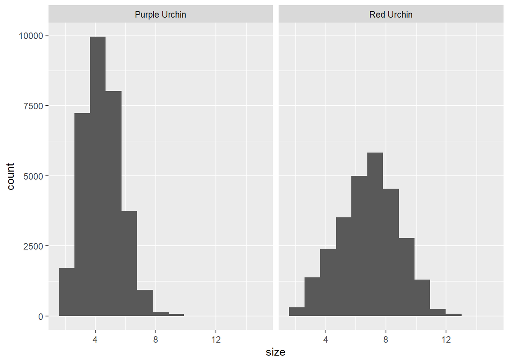

```r
ggplot(data= urchins, aes(x= size)) +
  geom_histogram(bins= 13)+
  facet_wrap(~common_name)
```

In this code chunk I will create a box plot.

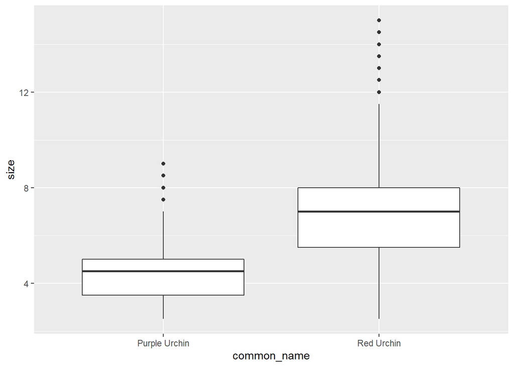

```r
ggplot(data= urchins, aes(x= common_name, y= size)) +
  geom_boxplot()
```

2. Now I will make a descriptive statistics table using group_by(common_name) and summarize() and making it more presentable using kabelExtra.

```r
summary_stats <- urchins %>%
  group_by(common_name) %>%
  summarize(
    mean_size= mean(size),
    meidan_size = median(size),
    sd_size = sd(size),
    Sample_count = n()
  )
summary_stats %>%
  kbl() %>%
  kable_styling()
```

| common_name | mean_size | meidan_size | sd_size | Sample_count |
| --- | --- | --- | --- | --- |
| Purple Urchin | 4.469797 | 4.5 | 1.175264 | 31805 |
| Red Urchin | 6.776489 | 7.0 | 1.891343 | 27408 |

#### Section 2

```r
urchins_clean <-urchins %>%
  mutate(date=mdy(date))
class(urchins_clean$date)
```

```
## [1] "Date"
```

1. I will now create a new subset of data containing only purple urchins data points. Also I will convert the date data to the “Date” class, also creating a new column that only contains the year. Lastly I will create a new column that only has full site name. But I also need to clean the dates to get them in the proper format.

```r
purple_urchins <- urchins_clean %>%
  filter(common_name == "Purple Urchin") %>%
  mutate(Date= ymd(date)) %>%
  mutate(year= year(Date)) %>%
  mutate(site_full= case_when(
     site %in% c("NAPL") ~ "Naples Reef",
     site %in% c("AQUE") ~ "Arroyo Quemado Reef",
     site %in% c("CARP") ~ "Carpinteria Reef",
     site %in% c("MOHK") ~ "Mohawk Reef",
     site %in% c("IVEE") ~ "Isla Vista Reef"

  ))
```

2. Next I will create a summary table containing the total number of purple urchins observed by site and year using group_by() and count().

```r
urchins_by_site_and_year <- purple_urchins %>%
  group_by(site_full, year) %>%
    count()
urchins_by_site_and_year
```

```
## # A tibble: 61 x 3
## # Groups:   site_full, year [61]
##    site_full            year     n
##    <chr>               <dbl> <int>
##  1 Arroyo Quemado Reef  2008    67
##  2 Arroyo Quemado Reef  2009   926
##  3 Arroyo Quemado Reef  2010   921
##  4 Arroyo Quemado Reef  2011   887
##  5 Arroyo Quemado Reef  2012   764
##  6 Arroyo Quemado Reef  2013   434
##  7 Arroyo Quemado Reef  2014   410
##  8 Arroyo Quemado Reef  2015   400
##  9 Arroyo Quemado Reef  2016   342
## 10 Arroyo Quemado Reef  2017   406
## # ... with 51 more rows
```

3. Now I will create an exploratory graph of the counts of purple urchins recorded at each site over time for the years.

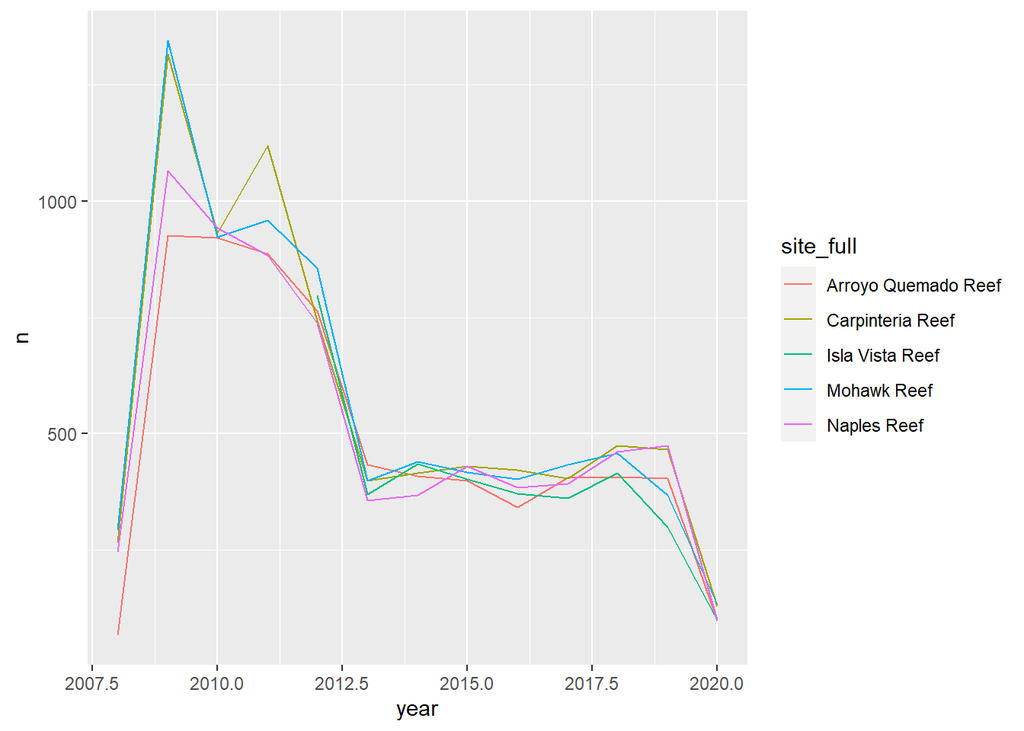

```r
ggplot(data= urchins_by_site_and_year,
       aes(x=year, y= n))+
  geom_line( aes(color= site_full))
```